# EDA_graphs

This is the page for EDA and graphs.

- Several summary tables and/or plots, each describing one, two or three variables in the data that you thought were interesting
- Explain the definitions of the variables in each table/plot
- Comment on the main features of each plot
- Include suitable labels and keys for each plot
- Make sure all plots would be readable if printed in black & white, and adjust the point sizes and/or line thicknesses to improve readability
- Lay out all tables so that they are clearly readable and clearly labelled, and do not use excessive significant figures
- All figures and tables should be numbered and should have captions

## Correlation matrix for our selected variables:

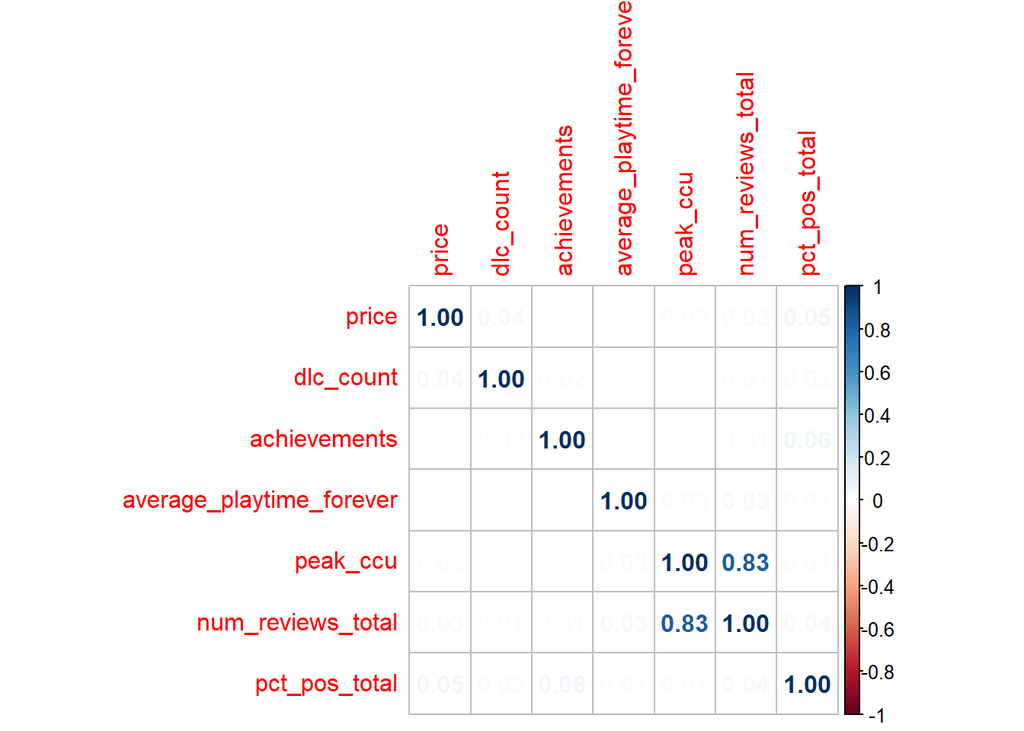

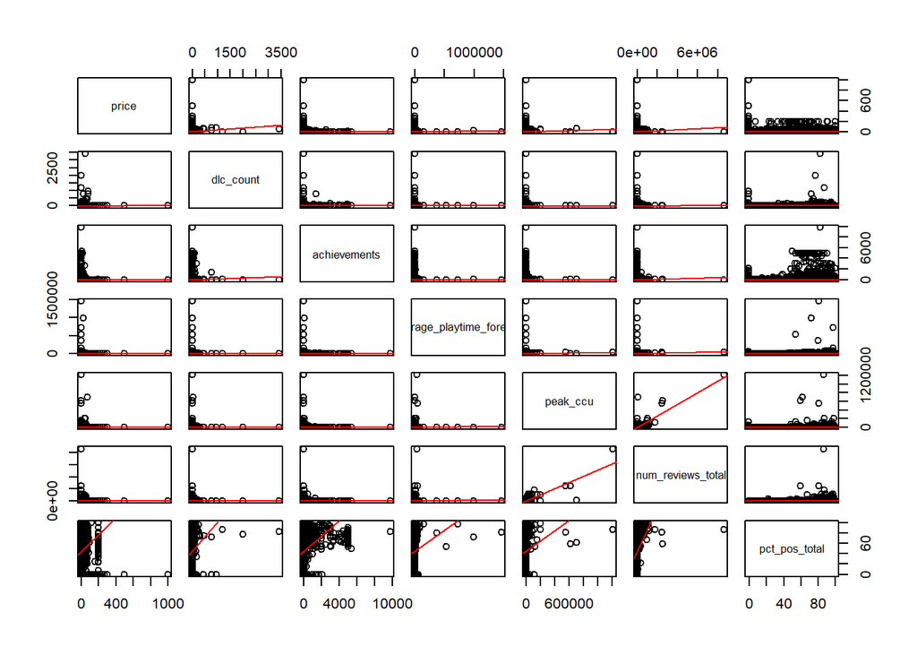

There is only one strong correlation between variables num_reviews_total and peak_ccu. Num_reviews_total is the total number of reviews that the game has received. This consists of both positive and negative reviews. Peak_ccu is the games current highest peak concurrent player record. This is the greatest number of players playing the specific game at the same time.

### Taking a look at Pirce variable

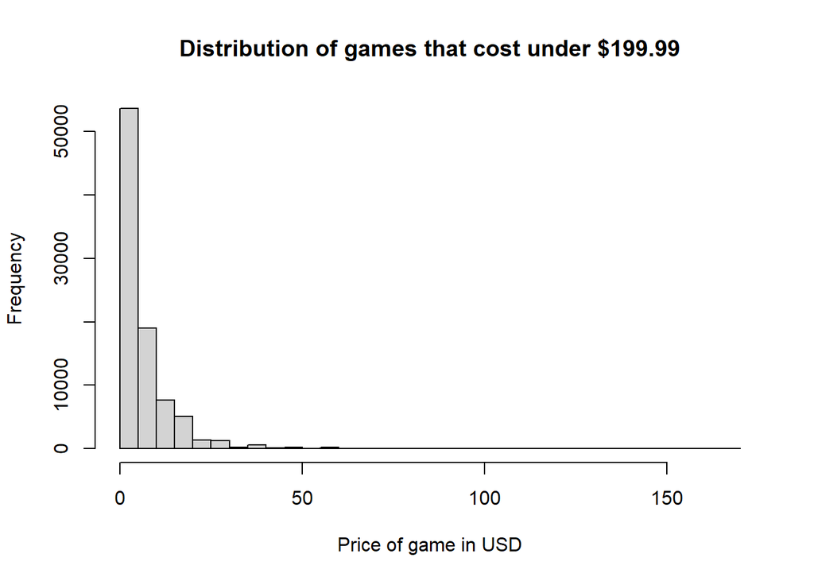

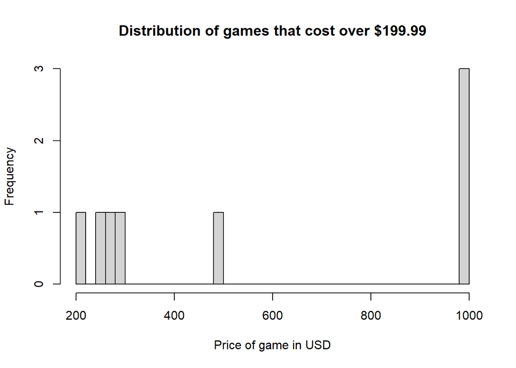

The variable price, denotes the base amount in USD that the game is priced at on Steam without any sales/discounts. The price variable shows a significant skew to the right where majority of the data points fall between 0-50. There are very few games that are priced above 199.99 USD, with there being three outliers that are all priced at 999.00 and 1000.00 USD.

| name | price |
| --- | --- |
| Beach Volleyball Competition | 219 |
| 3DF Zephyr Lite Steam Edition | 249 |
| Houdini Indie | 270 |
| Aartform Curvy 3D 3.0 | 299.9 |
| True Love | 500 |
| Ascent Free-Roaming VR Experience | 999 |
| The Leverage Game Business Edition | 1000 |
| The Leverage Game | 1000 |